# Happiness across countries

anastasia molotova

Загружаем данные:

```r
data <- readRDS("~/WVS_Cross-National_Wave_7_R_v1_6.rds")
```

или автоматически из файла;

Далее сразу отберем наши необходимые переменные и страны, чтобы не нагружать систему;

Согласно codebook, *156* это China, *643* это Russia, *840* это United States (из необходимых нам стран);

```r
library(tidyverse)
data = data %>% select(B_COUNTRY, Q46) %>% filter(B_COUNTRY == 156 | B_COUNTRY == 643 | B_COUNTRY == 840)
```

Также уберем лейблы для более удобной работы с данными:

```r
library(labelled)
data = remove_labels(data, user_na_to_na = TRUE)
```

Посмотрим на структуру:

```r
str(data)
```

```
## tibble [7,442 x 2] (S3: tbl_df/tbl/data.frame)
##  $ B_COUNTRY: num [1:7442] 156 156 156 156 156 156 156 156 156 156 ...
##  $ Q46      : num [1:7442] 2 1 1 2 1 2 2 2 2 2 ...
```

Очевидно, что обе переменные факторные по своей сути, а не числовые:

```r
library(magrittr)
data %<>% mutate_if(is.numeric, as.factor)
```

Проверим, что все сработало:

```r
levels(data$B_COUNTRY)
```

```
## [1] "156" "643" "840"
```

```r
levels(data$Q46)
```

```
## [1] "1" "2" "3" "4"
```

В 46 вопросе (про счастье) видим, что осталось 4 уровня (1-4), которые соответсвуют следующим значениям (по codebook):

- 1 == Very happy
- 2 == Quite happy
- 3 == Not very happy
- 4 == Not at all happy

Посмотрим на распределение внутри этих уровней:

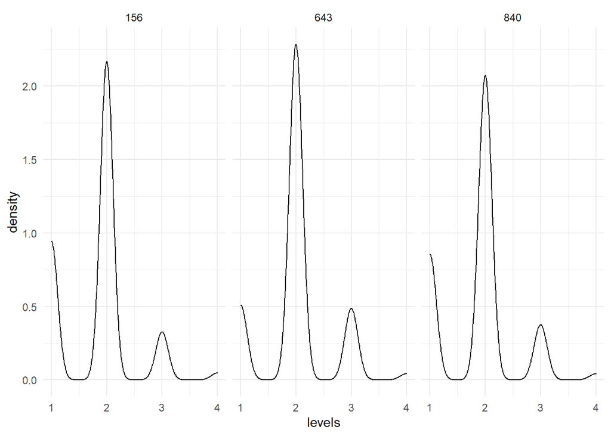

```r
ggplot(data)+
  geom_density(aes(x = as.numeric(Q46)))+
  xlab("levels")+
  facet_wrap(~B_COUNTRY)+
  theme_minimal()
```

Не совсем нормальное распределение внутри групп, чаще всего отвечали *quite happy*.

Для того, чтобы ответить на поставленные в задаче вопросы, проведем несколько статтестов:

```r
library(stats)
kruskal.test(data$Q46 ~ data$B_COUNTRY)
```

```
##
##  Kruskal-Wallis rank sum test
##
## data:  data$Q46 by data$B_COUNTRY
## Kruskal-Wallis chi-squared = 96.377, df = 2, p-value < 2.2e-16
```

Значение p-value меньше .05, значит мы можем говорить, что **существует статистически значимая разница в уровне счастья между странами**.

Чтобы ответить на вопрос о том, как различается счастье, нужно провести post-hoc analysis. Dunn тест поможет нам в этом:

```r
library(rstatix)
dunn_test(data = data, Q46 ~ B_COUNTRY)
```

```
## # A tibble: 3 x 9
##   .y.   group1 group2    n1    n2 statistic        p    p.adj p.adj.signif
## * <chr> <chr>  <chr>  <int> <int>     <dbl>    <dbl>    <dbl> <chr>
## 1 Q46   156    643     3035  1759      9.58 9.76e-22 2.93e-21 ****
## 2 Q46   156    840     3035  2588      1.98 4.78e- 2 4.78e- 2 *
## 3 Q46   643    840     1759  2588     -7.58 3.56e-14 7.12e-14 ****
```

Согласно аутпуту, **самые значимые различия наблюдаются между Китаем и Россией, а также Россией и США. Заметно менее значимы различия между Китаем и США**.

Эти различия могут быть обсуловлены разными причинам. Возможно, анализ нужно проводить как на так называемом “макро” (уровень государства: экономика, культура, медицина), так и на “микро” уровне (образование, возраст, работа, семейное положение).

Если говорить про условный уровень государства, то первым на ум приходит фактор “культура”. Многие исследования говорят о том, что важно учитывать *то, как люди стремятся быть счастливыми*, и это паттерны этого стремления уже во многом обусловлены культурой: для США *очень* важно быть счастливым (Joshanloo & Weijers, 2014), в то время как в России и на востоке это не так важно вследствие культурной специфики (Ford et al., 2015). Что касается уровня экономики, то он напрямую влияет на качество жизни (и, вероятнее всего, на уровень счастья): сложно быть счастливым, покупая на последние деньги хлеб. Здесь мне кажется важным связать этот фактор и с уровнем доступности медицины: чем качественнее оказывается медпомощь (никто не знает, что будет завтра), тем легче жить.

Если рассматривать “микро” уровень, то личностные достижения, безусловно, влияют на наше ощущения счастья. Достаточно показательным мне кажется пример, когда студент из маленького городка учится достаточно хорошо, чтобы поступить в крупный город, тем самым “выбиваясь в люди”, повышая свое благополучие. Для кого-то дети – смысл жизни, а кто-то радуется, когда получает повышение на любимой работе или вовсе уходит с нелюбимой.

Так, все эти факторы-пазлы складываются в одну достаточно субъективную мозайку под названием “счастье”. К сожалению, пока что мой анализ и еще некоторая статистика (Россию Признали Страной Для Грустных, Lenta) только подтверждают печально известную фразу “Россия для грустных”.

Визуализируем уровень счастья жителей Китая, России и США:

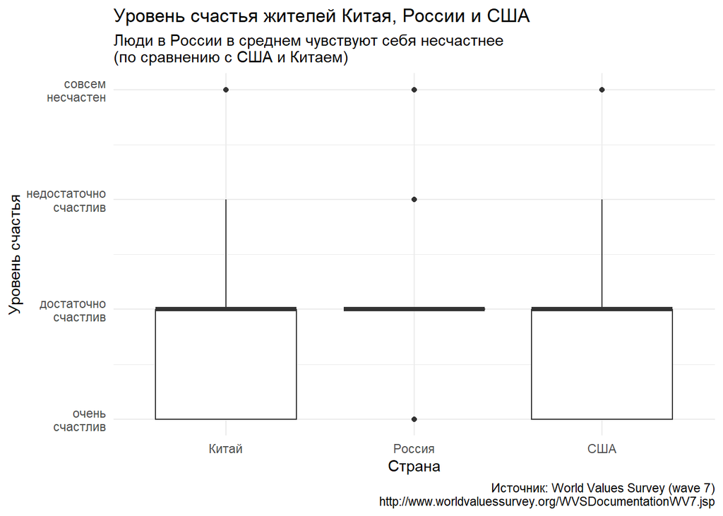

```r
ggplot(data = data, aes(x = B_COUNTRY, y = as.numeric(Q46)))+
  geom_boxplot(fatten = 3)+
  labs(title = "Уровень счастья жителей Китая, России и США",
       subtitle = "Люди в России в среднем чувствуют себя несчастнее\n(по сравнению с США и Китаем)",
       caption = "Источник: World Values Survey (wave 7)\nhttp://www.worldvaluessurvey.org/WVSDocumentationWV7.jsp",
       x = "Страна",
       y = "Уровень счастья")+
  scale_x_discrete(labels = c("Китай", "Россия", "США"))+
  scale_y_continuous(labels = c("очень\nсчастлив", "достаточно\nсчастлив", "недостаточно\nсчастлив", "совсем\nнесчастен"))+
  theme_minimal()
```

References:

- Haerpfer, C., Inglehart, R., Moreno, A., Welzel, C., Kizilova, K., Diez-Medrano J., M. Lagos, P. Norris, E. Ponarin & B. Puranen et al. (eds.). 2020. World Values Survey: Round Seven - Country-Pooled Datafile. Madrid, Spain & Vienna, Austria: JD Systems Institute & WVSA Secretariat. doi.org/10.14281/18241.1
- Ford, B. Q., Dmitrieva, J. O., Heller, D., Chentsova-Dutton, Y., Grossmann, I., Tamir, M., Uchida, Y., Koopmann-Holm, B., Floerke, V. A., Uhrig, M., Bokhan, T., & Mauss, I. B. (2015). Culture shapes whether the pursuit of happiness predicts higher or lower well-being. Journal of Experimental Psychology: General, 144(6), 1053–1062. https://doi.org/10.1037/xge0000108
- Joshanloo, M., & Weijers, D. (2014). Aversion to Happiness Across Cultures: A Review of Where and Why People are Averse to Happiness. Journal of Happiness Studies, 15(3), 717–735. https://doi.org/10.1007/s10902-013-9489-9
- Россию признали страной для грустных. Retrieved 14 February 2021, from https://lenta.ru/news/2019/09/18/so_sad/